# Huijun Yan midterm

```python
import pandas as pd
import numpy as np
import matplotlib.pyplot as plt
import seaborn as sns
from sklearn import linear_model
```

```python
bmx = pd.read_sas('BMX_I.XPT')
```

```python
bmx.head()
```

|  | SEQN | BMDSTATS | BMXWT | BMIWT | BMXRECUM | BMIRECUM | BMXHEAD | BMIHEAD | BMXHT | BMIHT | ... | BMXARMC | BMIARMC | BMXWAIST | BMIWAIST | BMXSAD1 | BMXSAD2 | BMXSAD3 | BMXSAD4 | BMDAVSAD | BMDSADCM |
| --- | --- | --- | --- | --- | --- | --- | --- | --- | --- | --- | --- | --- | --- | --- | --- | --- | --- | --- | --- | --- | --- |
| 0 | 83732.0 | 1.0 | 94.8 | NaN | NaN | NaN | NaN | NaN | 184.5 | NaN | ... | 35.9 | NaN | 101.1 | NaN | 22.9 | 22.7 | NaN | NaN | 22.8 | NaN |
| 1 | 83733.0 | 1.0 | 90.4 | NaN | NaN | NaN | NaN | NaN | 171.4 | NaN | ... | 33.2 | NaN | 107.9 | NaN | 27.5 | 27.1 | NaN | NaN | 27.3 | NaN |
| 2 | 83734.0 | 1.0 | 83.4 | NaN | NaN | NaN | NaN | NaN | 170.1 | NaN | ... | 31.0 | NaN | 116.5 | NaN | 26.7 | 26.5 | NaN | NaN | 26.6 | NaN |
| 3 | 83735.0 | 1.0 | 109.8 | NaN | NaN | NaN | NaN | NaN | 160.9 | NaN | ... | 38.3 | NaN | 110.1 | NaN | 25.2 | 25.0 | NaN | NaN | 25.1 | NaN |
| 4 | 83736.0 | 3.0 | 55.2 | NaN | NaN | NaN | NaN | NaN | 164.9 | NaN | ... | 27.2 | NaN | 80.4 | NaN | NaN | NaN | NaN | NaN | NaN | NaN |

5 rows × 26 columns

```python
print(bmx.shape)
```

```
(9544, 26)
```

```python
bmx.info()
```

```
<class 'pandas.core.frame.DataFrame'>
RangeIndex: 9544 entries, 0 to 9543
Data columns (total 26 columns):
SEQN        9544 non-null float64
BMDSTATS    9544 non-null float64
BMXWT       9445 non-null float64
BMIWT       443 non-null float64
BMXRECUM    1073 non-null float64
BMIRECUM    33 non-null float64
BMXHEAD     215 non-null float64
BMIHEAD     0 non-null float64
BMXHT       8769 non-null float64
BMIHT       105 non-null float64
BMXBMI      8756 non-null float64
BMDBMIC     3340 non-null float64
BMXLEG      7110 non-null float64
BMILEG      402 non-null float64
BMXARML     8976 non-null float64
BMIARML     420 non-null float64
BMXARMC     8976 non-null float64
BMIARMC     421 non-null float64
BMXWAIST    8313 non-null float64
BMIWAIST    489 non-null float64
BMXSAD1     6983 non-null float64
BMXSAD2     6983 non-null float64
BMXSAD3     353 non-null float64
BMXSAD4     353 non-null float64
BMDAVSAD    6983 non-null float64
BMDSADCM    446 non-null float64
dtypes: float64(26)
memory usage: 1.9 MB
```

```python
demo = pd.read_sas('DEMO_I.XPT')
```

```python
print(demo.shape)
```

```
(9971, 47)
```

```python
demo.head()
```

|  | SEQN | SDDSRVYR | RIDSTATR | RIAGENDR | RIDAGEYR | RIDAGEMN | RIDRETH1 | RIDRETH3 | RIDEXMON | RIDEXAGM | ... | DMDHREDU | DMDHRMAR | DMDHSEDU | WTINT2YR | WTMEC2YR | SDMVPSU | SDMVSTRA | INDHHIN2 | INDFMIN2 | INDFMPIR |
| --- | --- | --- | --- | --- | --- | --- | --- | --- | --- | --- | --- | --- | --- | --- | --- | --- | --- | --- | --- | --- | --- |
| 0 | 83732.0 | 9.0 | 2.0 | 1.0 | 62.0 | NaN | 3.0 | 3.0 | 1.0 | NaN | ... | 5.0 | 1.0 | 3.0 | 134671.370419 | 135629.507405 | 1.0 | 125.0 | 10.0 | 10.0 | 4.39 |
| 1 | 83733.0 | 9.0 | 2.0 | 1.0 | 53.0 | NaN | 3.0 | 3.0 | 1.0 | NaN | ... | 3.0 | 3.0 | NaN | 24328.560239 | 25282.425927 | 1.0 | 125.0 | 4.0 | 4.0 | 1.32 |
| 2 | 83734.0 | 9.0 | 2.0 | 1.0 | 78.0 | NaN | 3.0 | 3.0 | 2.0 | NaN | ... | 3.0 | 1.0 | 3.0 | 12400.008522 | 12575.838818 | 1.0 | 131.0 | 5.0 | 5.0 | 1.51 |
| 3 | 83735.0 | 9.0 | 2.0 | 2.0 | 56.0 | NaN | 3.0 | 3.0 | 2.0 | NaN | ... | 5.0 | 6.0 | NaN | 102717.995647 | 102078.634508 | 1.0 | 131.0 | 10.0 | 10.0 | 5.00 |
| 4 | 83736.0 | 9.0 | 2.0 | 2.0 | 42.0 | NaN | 4.0 | 4.0 | 2.0 | NaN | ... | 4.0 | 3.0 | NaN | 17627.674984 | 18234.736219 | 2.0 | 126.0 | 7.0 | 7.0 | 1.23 |

5 rows × 47 columns

```python
demo.info()
```

```
<class 'pandas.core.frame.DataFrame'>
RangeIndex: 9971 entries, 0 to 9970
Data columns (total 47 columns):
SEQN        9971 non-null float64
SDDSRVYR    9971 non-null float64
RIDSTATR    9971 non-null float64
RIAGENDR    9971 non-null float64
RIDAGEYR    9971 non-null float64
RIDAGEMN    695 non-null float64
RIDRETH1    9971 non-null float64
RIDRETH3    9971 non-null float64
RIDEXMON    9544 non-null float64
RIDEXAGM    4060 non-null float64
DMQMILIZ    6149 non-null float64
DMQADFC     527 non-null float64
DMDBORN4    9971 non-null float64
DMDCITZN    9969 non-null float64
DMDYRSUS    2236 non-null float64
DMDEDUC3    2647 non-null float64
DMDEDUC2    5719 non-null float64
DMDMARTL    5719 non-null float64
RIDEXPRG    1288 non-null float64
SIALANG     9971 non-null float64
SIAPROXY    9970 non-null float64
SIAINTRP    9971 non-null float64
FIALANG     9642 non-null float64
FIAPROXY    9642 non-null float64
FIAINTRP    9642 non-null float64
MIALANG     6977 non-null float64
MIAPROXY    6978 non-null float64
MIAINTRP    6978 non-null float64
AIALANGA    5962 non-null float64
DMDHHSIZ    9971 non-null float64
DMDFMSIZ    9971 non-null float64
DMDHHSZA    9971 non-null float64
DMDHHSZB    9971 non-null float64
DMDHHSZE    9971 non-null float64
DMDHRGND    9971 non-null float64
DMDHRAGE    9971 non-null float64
DMDHRBR4    9575 non-null float64
DMDHREDU    9575 non-null float64
DMDHRMAR    9909 non-null float64
DMDHSEDU    5226 non-null float64
WTINT2YR    9971 non-null float64
WTMEC2YR    9971 non-null float64
SDMVPSU     9971 non-null float64
SDMVSTRA    9971 non-null float64
INDHHIN2    9626 non-null float64
INDFMIN2    9642 non-null float64
INDFMPIR    8919 non-null float64
dtypes: float64(47)
memory usage: 3.6 MB
```

```python
merged = bmx.merge(right = demo, on = 'SEQN')
```

```python
print(merged.head())
```

```
      SEQN  BMDSTATS  BMXWT  BMIWT  BMXRECUM  BMIRECUM  BMXHEAD  BMIHEAD  \
0  83732.0       1.0   94.8    NaN       NaN       NaN      NaN      NaN
1  83733.0       1.0   90.4    NaN       NaN       NaN      NaN      NaN
2  83734.0       1.0   83.4    NaN       NaN       NaN      NaN      NaN
3  83735.0       1.0  109.8    NaN       NaN       NaN      NaN      NaN
4  83736.0       3.0   55.2    NaN       NaN       NaN      NaN      NaN

   BMXHT  BMIHT    ...     DMDHREDU  DMDHRMAR  DMDHSEDU       WTINT2YR  \
0  184.5    NaN    ...          5.0       1.0       3.0  134671.370419
1  171.4    NaN    ...          3.0       3.0       NaN   24328.560239
2  170.1    NaN    ...          3.0       1.0       3.0   12400.008522
3  160.9    NaN    ...          5.0       6.0       NaN  102717.995647
4  164.9    NaN    ...          4.0       3.0       NaN   17627.674984

        WTMEC2YR  SDMVPSU  SDMVSTRA  INDHHIN2  INDFMIN2  INDFMPIR
0  135629.507405      1.0     125.0      10.0      10.0      4.39
1   25282.425927      1.0     125.0       4.0       4.0      1.32
2   12575.838818      1.0     131.0       5.0       5.0      1.51
3  102078.634508      1.0     131.0      10.0      10.0      5.00
4   18234.736219      2.0     126.0       7.0       7.0      1.23

[5 rows x 72 columns]
```

```python
print(merged.shape)
```

```
(9544, 72)
```

# Baby Weights: [40 pts]

Guiding question: Do baby boys weigh more than baby girls on average?

• [5 pts] Calculate and display the mean weight of baby boys for each month, from month 0 to 12. You’ll produce 13 values, one for each month.

• [5 pts] Calculate and display the mean weight of baby girls for each month, from month 0 to 12.

• [5 pts] Calculate and display the difference between the mean weights of boys and girls for each month.

• [10 pts] Make a line plot showing two lines: one for boys’ mean weights months 0-12, and one for girls’ mean weights 0-12 (in a different color). The month will go on the x-axis, and the mean weight will go on the y-axis.

• [10 pts] (with seaborn) Make a scatterplot with linear regression lines for the baby boys’ relationship between age and wt, and the baby girls’ relationship between age and wt.

• [5 pts + up to 5 pts bonus if excellent] Comment on what you think the data says about the guiding question. Include any additional analysis you deem appropriate.

• [5 pts] Calculate and display the mean weight of baby boys for each month, from month 0 to 12. You’ll produce 13 values, one for each month.

```python
babies = merged.loc[merged['RIDAGEMN'].isnull() == False]
boybaby = babies.loc[((babies.RIDAGEMN.values.astype(int) <= 12) & (babies.RIAGENDR==1)),]
boyweight = boybaby.groupby("RIDAGEMN")["BMXWT"].mean()
print(boyweight)
```

```
RIDAGEMN
5.397605e-79     4.794444
1.000000e+00     5.791667
2.000000e+00     6.661111
3.000000e+00     7.000000
4.000000e+00     7.795000
5.000000e+00     8.525000
6.000000e+00     8.263636
7.000000e+00     9.061111
8.000000e+00     9.322222
9.000000e+00    10.093750
1.000000e+01    10.364286
1.100000e+01     9.963636
1.200000e+01    10.523077
Name: BMXWT, dtype: float64
```

• [5 pts] Calculate and display the mean weight of baby girls for each month, from month 0 to 12.

```python
girlbaby = babies.loc[((babies.RIDAGEMN.values.astype(int) <= 12) & (babies.RIAGENDR==2)),]
girlweight = girlbaby.groupby("RIDAGEMN")["BMXWT"].mean()
print(girlweight)
```

```
RIDAGEMN
5.397605e-79    4.508333
1.000000e+00    5.457143
2.000000e+00    5.712500
3.000000e+00    6.553846
4.000000e+00    7.052941
5.000000e+00    7.647059
6.000000e+00    8.005263
7.000000e+00    8.190909
8.000000e+00    8.303704
9.000000e+00    9.243750
1.000000e+01    9.066667
1.100000e+01    9.100000
1.200000e+01    9.757143
Name: BMXWT, dtype: float64
```

• [5 pts] Calculate and display the difference between the mean weights of boys and girls for each month.

```python
diff = boyweight - girlweight
print(diff)
```

```
RIDAGEMN
5.397605e-79    0.286111
1.000000e+00    0.334524
2.000000e+00    0.948611
3.000000e+00    0.446154
4.000000e+00    0.742059
5.000000e+00    0.877941
6.000000e+00    0.258373
7.000000e+00    0.870202
8.000000e+00    1.018519
9.000000e+00    0.850000
1.000000e+01    1.297619
1.100000e+01    0.863636
1.200000e+01    0.765934
Name: BMXWT, dtype: float64
```

• [10 pts] Make a line plot showing two lines: one for boys’ mean weights months 0-12, and one for girls’ mean weights 0-12 (in a different color). The month will go on the x-axis, and the mean weight will go on the y-axis.

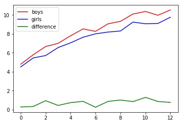

```python
month = np.arange(0,13,1)
plt.plot(month,boyweight,color="red")
plt.plot(month,girlweight,color="blue")
plt.plot(month,diff,color="green")
plt.legend(["boys","girls","difference"])
plt.show()
```

• [10 pts] (with seaborn) Make a scatterplot with linear regression lines for the baby boys’ relationship between age and wt, and the baby girls’ relationship between age and wt.

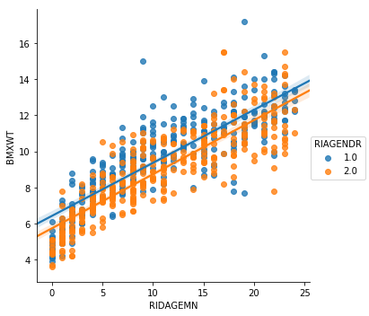

```python
sns.lmplot(x="RIDAGEMN",y="BMXWT", hue="RIAGENDR",data=babies)
plt.show()
```

• [5 pts + up to 5 pts bonus if excellent] Comment on what you think the data says about the guiding question. Include any additional analysis you deem appropriate.

Do baby boys weigh more than baby girls on average?

Based on the line plot above, we can see that baby boys weight are more than baby girls weight on average because the line of boys' mean weights months 0-12 is above the line of girls' mean weights months 0-12. Besides, based on the scatterplot above, we also found that the line of baby boys' relationship between age and weight is above the line of baby girls' relationship between age and weight. Therefore, I think that baby boys weight are more than baby girls weight on average.

# Height vs leg length vs arm length: [35pts]

Guiding question: What’s the relationship between height and leg length and arm length. Does this relationship change with age? For all adults aged 20 and up, who have all three measurements of height, upper leg length, and upper arm length:

• [3 pts] What is the correlation between standing height and upper leg length?

• [3 pts] What is the correlation between standing height and upper arm length?

• [3 pts] What is the correlation between upper leg length and upper arm length?

• Make adult age groups by decade: i.e. adults aged 20-29.9, adults aged 30-39.9, … adults aged 70-79.9, adults aged 80+ (7 groups total). (not required, but recommended: use pandas.cut … this function was not explicitly covered in the notes, but you should be able to read the documentation to learn function usage. If you use this, set option: right=False)

• [10 pts] For each age group, calculate the mean of the three values.

• [10 pts] We want to make a plot with three lines showing the relationship between the age decade and the mean height, leg length, and arm length. o However, because leg length and arm length are similar in scale, but height is not, create an ‘adjusted height’ column which is the mean height minus 128 cm.

o Plot three lines: adjusted height, leg length, arm length.

o The x-axis will be the age decade, and the y-axis will be the mean measurement for each age group.

o Be sure to include a legend

• [6 pts + up to 5 pts bonus if excellent] Comment on what you think the data says about the guiding question. Include any additional analysis you deem appropriate.

• [3 pts] What is the correlation between standing height and upper leg length?

```python
adult20 = merged.loc[((merged['RIDAGEYR'].isnull() == False) &
                      (merged.RIDAGEYR.values.astype(int) >=20)) &
                     (merged['BMXHT'].isnull() == False) &
                     (merged['BMXLEG'].isnull() == False) &
                     (merged['BMXARML'].isnull() == False),
                     ['RIDAGEYR','BMXHT','BMXLEG','BMXARML']]
print(adult20[["BMXHT","BMXLEG"]].corr())
```

```
           BMXHT    BMXLEG
BMXHT   1.000000  0.787449
BMXLEG  0.787449  1.000000
```

• [3 pts] What is the correlation between standing height and upper arm length?

```python
print(adult20[["BMXHT","BMXARML"]].corr())
```

```
            BMXHT   BMXARML
BMXHT    1.000000  0.797873
BMXARML  0.797873  1.000000
```

• [3 pts] What is the correlation between upper leg length and upper arm length?

```python
print(adult20[["BMXLEG","BMXARML"]].corr())
```

```
           BMXLEG   BMXARML
BMXLEG   1.000000  0.629369
BMXARML  0.629369  1.000000
```

• Make adult age groups by decade: i.e. adults aged 20-29.9, adults aged 30-39.9, … adults aged 70-79.9, adults aged 80+ (7 groups total). (not required, but recommended: use pandas.cut … this function was not explicitly covered in the notes, but you should be able to read the documentation to learn function usage. If you use this, set option: right=False)

```python
adult20["agegroups"] = pd.cut(adult20.RIDAGEYR,bins=np.arange(20,99,10),right=False)
adult20.agegroups
```

```
0       [60, 70)
1       [50, 60)
2       [70, 80)
3       [50, 60)
4       [40, 50)
5       [70, 80)
9       [20, 30)
10      [30, 40)
12      [50, 60)
15      [40, 50)
18      [40, 50)
20      [30, 40)
22      [60, 70)
23      [60, 70)
25      [50, 60)
```

[output cut: 48 more lines]

• [10 pts] For each age group, calculate the mean of the three values.

```python
summary = adult20.groupby('agegroups')[["BMXHT","BMXLEG","BMXARML"]].mean()
print(summary)
```

```
                BMXHT     BMXLEG    BMXARML
agegroups
[20, 30)   167.879617  40.064189  37.068919
[30, 40)   167.488202  39.556128  37.154754
[40, 50)   166.563244  38.680863  37.094632
[50, 60)   166.351476  38.163400  37.188784
[60, 70)   164.977480  37.342707  37.252859
[70, 80)   164.728016  36.984049  37.350102
[80, 90)   162.097091  36.516000  36.908000
```

• [10 pts] We want to make a plot with three lines showing the relationship between the age decade and the mean height, leg length, and arm length.

o However, because leg length and arm length are similar in scale, but height is not, create an ‘adjusted height’ column which is the mean height minus 128 cm.

o Plot three lines: adjusted height, leg length, arm length.

o The x-axis will be the age decade, and the y-axis will be the mean measurement for each age group.

o Be sure to include a legend

```python
summary.index = np.arange(20,90,10)
summary["adjusted height"]= summary["BMXHT"]-128
print(summary)
```

```
         BMXHT     BMXLEG    BMXARML  adjusted height
20  167.879617  40.064189  37.068919        39.879617
30  167.488202  39.556128  37.154754        39.488202
40  166.563244  38.680863  37.094632        38.563244
50  166.351476  38.163400  37.188784        38.351476
60  164.977480  37.342707  37.252859        36.977480
70  164.728016  36.984049  37.350102        36.728016
80  162.097091  36.516000  36.908000        34.097091
```

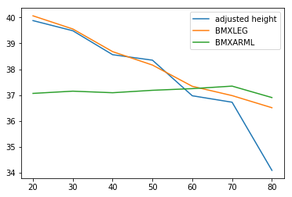

```python
summary[["adjusted height","BMXLEG","BMXARML"]].plot()
plt.legend()
plt.show()
```

• [6 pts + up to 5 pts bonus if excellent] Comment on what you think the data says about the guiding question. Include any additional analysis you deem appropriate.

What’s the relationship between height and leg length and arm length. Does this relationship change with age?

The relationship between height and leg length: We can see that the correlation coefficient for the relation between standing height and upper leg length is 0.787449. It means that they are with a pretty strong positive correlation.

The relationship between height and arm length: We can see that the correlation coefficient for the relation between standing height and upper arm length is 0.797873. It means that they are with a pretty strong positive correlation.

The relationship between leg length and arm length: We can see that the correlation coefficient for the relation between upper leg length and upper arm length is 0.629369. It means that they are with a strong positive correlation.

Besides, based on the line plot above, we found that as the age increase, both standing height and upper leg length are decreased. However, we can see that as the age increase, the upper arm length will not affect a lot.

Thus, we can conclude that the relationship between height and leg length will not change with age. However, both the relationship between height and arm length, and the relationship between leg length and arm length will change with age.

# Education Level and income [25pts]

Guiding question: Is the Education level of the head of the household related to household income?

• Use the variable: INDHHIN2 for household income. Use DMDHREDU for the education level of the head of the household.

• Filter to adults aged 20 and older.

• Remove people who are missing, refused to answer, or didn’t know the household income or education levels.

• Remove household income categories 12 ($20,000 and over) and 13 (under $20,000) as they don’t quite fit in with the other income categories.

• [5 pts] Print the shape of the resulting data before the next step.

• [15 pts] Summarize and display the data to explore the relationship between education level and income. This question is purposely open-ended. You choose how best to summarize and display the data to answer the question regarding education level and household income.

• [5 pts + up to 5 pts bonus if excellent] Be sure to comment on what you think the data and displays say about the guiding question. Say a little more than “more education - more money.” Yes, that is the relationship you’ll see, but elaborate a little more. For example, at what point does education make a difference?

• Use the variable: INDHHIN2 for household income. Use DMDHREDU for the education level of the head of the household.

• Filter to adults aged 20 and older.

• Remove people who are missing, refused to answer, or didn’t know the household income or education levels.

• Remove household income categories 12 ($20,000 and over) and 13 (under $20,000) as they don’t quite fit in with the other income categories.

```python
df = merged.loc[((~merged.INDHHIN2.isnull()) &
                 (~merged.DMDHREDU.isnull()) &
                 (merged.INDHHIN2!=77) &
                 (merged.INDHHIN2!=99) &
                 (merged.DMDHREDU!=7) &
                 (merged.DMDHREDU!=9) &
                 (merged.RIDAGEYR.values.astype(int) >=20)&
                 (~merged.RIDAGEYR.isnull()) &
                 (merged.INDHHIN2!=12) &
                 (merged.INDHHIN2!=13)),
                ("RIDAGEYR","INDHHIN2","DMDHREDU")]
df.info()
```

```
<class 'pandas.core.frame.DataFrame'>
Int64Index: 4720 entries, 0 to 9543
Data columns (total 3 columns):
RIDAGEYR    4720 non-null float64
INDHHIN2    4720 non-null float64
DMDHREDU    4720 non-null float64
dtypes: float64(3)
memory usage: 147.5 KB
```

• [5 pts] Print the shape of the resulting data before the next step.

```python
print(df.shape)
```

```
(4720, 3)
```

• [15 pts] Summarize and display the data to explore the relationship between education level and income. This question is purposely open-ended. You choose how best to summarize and display the data to answer the question regarding education level and household income.

```python
summary = pd.crosstab(df.INDHHIN2,df.DMDHREDU,rownames=['INDHHIN2'], colnames=['DMDHREDU'])
print(summary)
```

```
DMDHREDU  1.0  2.0  3.0  4.0  5.0
INDHHIN2
1.0        23   25   31   24   12
2.0        51   43   45   42   15
3.0        80   62   80   78   21
4.0        62   48   97   92   36
5.0        63   49   73  109   38
6.0        76   79  155  183   79
7.0        56   71  102  173   95
8.0        34   50  109  159   70
9.0        16   38   63  115   96
10.0       13   29   50   81   87
14.0       17   27   74  166  202
15.0       18   24  117  211  486
```

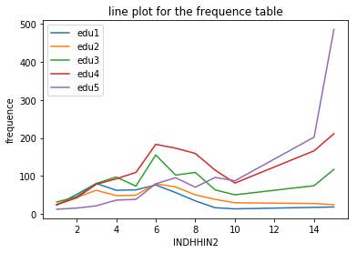

```python
plt.plot(summary)
plt.xlabel("INDHHIN2")
plt.ylabel("frequence")
plt.title("line plot for the frequence table")
plt.legend(["edu1","edu2","edu3","edu4","edu5"])
plt.show()
```

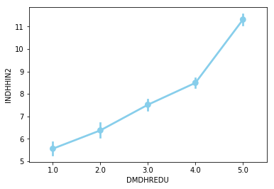

```python
sns.pointplot(df.DMDHREDU,df.INDHHIN2,color="skyblue")
plt.show()
```

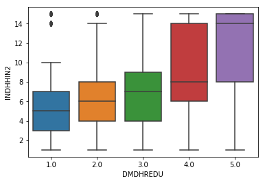

```python
sns.boxplot(x="DMDHREDU",y="INDHHIN2",data=df)
plt.show()
```

Based on the boxplot above, we can see that as the education level increase, the medians (which generally will be close to the average) of the household income also increase.

• [5 pts + up to 5 pts bonus if excellent] Be sure to comment on what you think the data and displays say about the guiding question. Say a little more than “more education - more money.” Yes, that is the relationship you’ll see, but elaborate a little more. For example, at what point does education make a difference?

Is the Education level of the head of the household related to household income?

Based on the boxplot above, we can see that as the education level increase, the medians (which generally will be close to the average) of the household income also increase.

Therefore, I think that household income will make a more difference at the point of education level 4 and 5.